# Intesity of Ki67 after auxin addition

Tom van Schaik

09 June, 2021

### Introduction

The goal of this analysis is to determine the downregulation of Ki67 after auxin-mediated knockdown. I have images of HCT116 Ki67 AID 2-4 (Takagi, et al.). Microscopy looked good for the GFP fusion, and less so for the antibody staining. Let’s quantify.

Update ts210408: I repeated microscopy of Ki67-AID IAA-mediated depletion, this time with two different antibodies. However, I took 2D images rather than 3D images. Let’s quantify. I might want to make 3D images in the end, but on the other hand this could be enough.

### Setup

Load the required libraries.

```r
# Load libraries
library(ggplot2)
library(tidyverse)
library(ggbeeswarm)

# Input data
results_dir <- c("../ts210402_E1546_confocal_Ki67_antibodies/ts210402_HCT116_Ki67AID_Ki67_depletion/ts210402_HCT116_Ki67AID_Ki67_depletion_analysis/")

# Prepare output directory
output_dir <- "ts210609_ki67_intensity_following_auxin_depletion_other_antibodies_2D"
dir.create(output_dir, showWarnings = FALSE)

# Prepare output files
```

```r
library(knitr)
opts_chunk$set(dev=c('png', 'pdf'), fig.path = file.path(output_dir, "figures/"),
               cache = T)
pdf.options(useDingbats = FALSE)
```

### 1) Prepare metadata

List the different samples.

```r
# List and organize all files
metadata <- tibble(cell_statistics = dir(results_dir, recursive = T,
                                         full.names = T,
                                         pattern = "dapi_statistics")) %>%
  mutate(sample = str_remove(basename(cell_statistics),
                             "_dapi.*"),
         sample = str_remove(sample, "M_")) %>%
  separate(sample, remove = F,
           c("cell", "replicate", "target", "condition", "slide")) %>%
  mutate(condition = recode(condition,
                            minusIAA = "ctrl",
                            plusIAA = "IAA"),
         condition = factor(condition, levels = c("ctrl", "IAA")),
         replicate = factor(replicate, levels = c("r1", "r2", "r3")),
         target = factor(target, levels = c("HPA", "NOV"))) %>%
  mutate(dapi = str_replace(cell_statistics,
                            "M_", "Q_"),
         dapi = str_remove(dapi, "_statistics"),
         gfp = str_replace(dapi, "dapi", "mki67ip"),
         ki67 = str_replace(dapi, "dapi", "ki67")) %>%
  arrange(target, condition, replicate, slide)

# Print metadata
metadata %>%
  print(n = Inf)
```

```
## # A tibble: 24 x 10
##    cell_statistics sample cell  replicate target condition slide dapi  gfp
##    <chr>           <chr>  <chr> <fct>     <fct>  <fct>     <chr> <chr> <chr>
##  1 ../ts210402_E1… HCT11… HCT1… r1        HPA    ctrl      004   ../t… ../t…
##  2 ../ts210402_E1… HCT11… HCT1… r1        HPA    ctrl      006   ../t… ../t…
##  3 ../ts210402_E1… HCT11… HCT1… r1        HPA    ctrl      008   ../t… ../t…
##  4 ../ts210402_E1… HCT11… HCT1… r2        HPA    ctrl      003   ../t… ../t…
##  5 ../ts210402_E1… HCT11… HCT1… r2        HPA    ctrl      005   ../t… ../t…
##  6 ../ts210402_E1… HCT11… HCT1… r2        HPA    ctrl      007   ../t… ../t…
##  7 ../ts210402_E1… HCT11… HCT1… r1        HPA    IAA       002   ../t… ../t…
##  8 ../ts210402_E1… HCT11… HCT1… r1        HPA    IAA       004   ../t… ../t…
##  9 ../ts210402_E1… HCT11… HCT1… r1        HPA    IAA       006   ../t… ../t…
## 10 ../ts210402_E1… HCT11… HCT1… r2        HPA    IAA       002   ../t… ../t…
## 11 ../ts210402_E1… HCT11… HCT1… r2        HPA    IAA       004   ../t… ../t…
## 12 ../ts210402_E1… HCT11… HCT1… r2        HPA    IAA       006   ../t… ../t…
## 13 ../ts210402_E1… HCT11… HCT1… r1        NOV    ctrl      002   ../t… ../t…
## 14 ../ts210402_E1… HCT11… HCT1… r1        NOV    ctrl      004   ../t… ../t…
## 15 ../ts210402_E1… HCT11… HCT1… r1        NOV    ctrl      006   ../t… ../t…
## 16 ../ts210402_E1… HCT11… HCT1… r2        NOV    ctrl      002   ../t… ../t…
## 17 ../ts210402_E1… HCT11… HCT1… r2        NOV    ctrl      005   ../t… ../t…
## 18 ../ts210402_E1… HCT11… HCT1… r2        NOV    ctrl      008   ../t… ../t…
## 19 ../ts210402_E1… HCT11… HCT1… r1        NOV    IAA       002   ../t… ../t…
## 20 ../ts210402_E1… HCT11… HCT1… r1        NOV    IAA       004   ../t… ../t…
## 21 ../ts210402_E1… HCT11… HCT1… r1        NOV    IAA       006   ../t… ../t…
## 22 ../ts210402_E1… HCT11… HCT1… r2        NOV    IAA       002   ../t… ../t…
## 23 ../ts210402_E1… HCT11… HCT1… r2        NOV    IAA       005   ../t… ../t…
## 24 ../ts210402_E1… HCT11… HCT1… r2        NOV    IAA       007   ../t… ../t…
## # … with 1 more variable: ki67 <chr>
```

### 2) Load cell sizes and create a cell table

Load the cells and show the sizes. Possibly filter on those.

```r
# Load all cells
LoadCells <- function(i) {
  tib <- read_tsv(metadata$cell_statistics[i]) %>%
    dplyr::select(c(2, 6, 8)) %>%
    rename_all(~c("object", "volume", "surface")) %>%
    add_column(sample = metadata$sample[i],
               condition = metadata$condition[i],
               slide = metadata$slide[i],
               target = metadata$target[i],
               replicate = metadata$replicate[i]) %>%
    mutate(cell_id = paste(sample, object, sep = "_"))

  tib

}

tib_cells <- lapply(1:nrow(metadata), LoadCells) %>%
  purrr::reduce(bind_rows)
```

Plot and filter these cells.

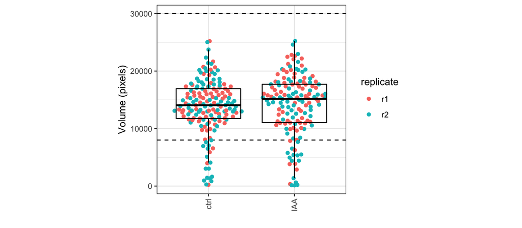

```r
# Set size limits
limits_size <- c(8e3, 3e4)

# Plot cell volume
tib_cells %>%
  ggplot(aes(x = condition, y = volume, col = replicate)) +
  geom_hline(yintercept = limits_size, col = "black", linetype = "dashed") +
  geom_quasirandom() +
  geom_boxplot(fill = NA, col = "black", outlier.shape = NA) +
  xlab("") +
  ylab("Volume (pixels)") +
  theme_bw() +
  theme(aspect.ratio = 1,
        axis.text.x = element_text(angle = 90, vjust = 0.5, hjust=1))
```

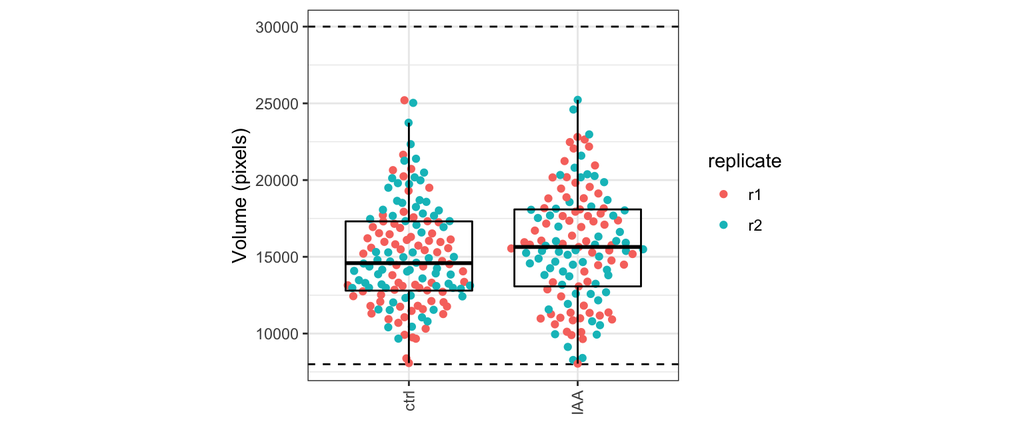

```r
# Filter cells for cutoff
tib_cells <- tib_cells %>%
  mutate(size_filter = volume >= limits_size[1] &
           volume <= limits_size[2])

tib_cells %>%
  filter(size_filter == T) %>%
  ggplot(aes(x = condition, y = volume, col = replicate)) +
  geom_hline(yintercept = limits_size, col = "black", linetype = "dashed") +
  geom_quasirandom() +
  geom_boxplot(fill = NA, col = "black", outlier.shape = NA) +
  xlab("") +
  ylab("Volume (pixels)") +
  theme_bw() +
  theme(aspect.ratio = 1,
        axis.text.x = element_text(angle = 90, vjust = 0.5, hjust=1))
```

### 3) Load the intensities

Load the intensities of the various channels (DAPI, gfp, Ki67).

```r
# Load all cells
LoadIntensities <- function(i) {

  # Load sizes
  tib <- read_tsv(metadata$dapi[i]) %>%
    dplyr::select(2, 6) %>%
    rename_all(~c("object", "dapi")) %>%
    add_column(sample = metadata$sample[i],
               condition = metadata$condition[i],
               target = metadata$target[i],
               slide = metadata$slide[i],
               replicate = metadata$replicate[i]) %>%
    mutate(cell_id = paste(sample, object, sep = "_"))

  # Load overlap with cells and lamina
  tib_gfp <- read_tsv(metadata$gfp[i]) %>%
    dplyr::select(6) %>%
    rename_all(~c("gfp"))

  tib_ki67 <- read_tsv(metadata$ki67[i]) %>%
    dplyr::select(6) %>%
    rename_all(~c("ki67"))

  # Combine all
  tib <- bind_cols(tib, tib_gfp, tib_ki67) %>%
    arrange(condition, slide, object)

  tib

}

tib_intensities <- lapply(1:nrow(metadata), LoadIntensities) %>%
  purrr::reduce(bind_rows)

# Filter out cells that did not pass the cell size filter
tib_intensities <- tib_intensities %>%
  dplyr::filter(cell_id %in% (tib_cells %>%
                                filter(size_filter == T) %>%
                                pull(cell_id)))
```

Plot various numbers of the targets.

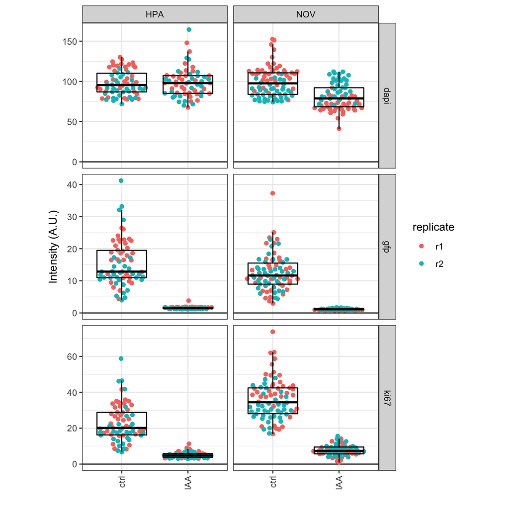

```r
# Plot intensity per cell
value_norm_limit <- 5

tib_gather <- tib_intensities %>%
  mutate(volume = tib_cells$volume[match(tib_intensities$cell_id,
                                         tib_cells$cell_id)]) %>%
  filter(cell_id != "minusIAA_007_34") %>%
  gather(key, value, dapi, gfp, ki67) %>%
  mutate(key = factor(key, levels = c("dapi", "gfp", "ki67")),
         value_norm = value * volume) %>%
  group_by(key, target, replicate) %>%
  mutate(value_norm = value_norm / quantile(value_norm, 0.8) * 10,
         shape = ifelse(value_norm < value_norm_limit,
                        "-", "cut"),
         value_norm_cut = ifelse(value_norm < value_norm_limit,
                                 value_norm, 0.5)) %>%
  ungroup()

tib_gather %>%
  ggplot(aes(x = condition, y = value, col = replicate)) +
  geom_hline(yintercept = 0, col = "black", linetype = "solid") +
  geom_quasirandom() +
  geom_boxplot(fill = NA, col = "black", outlier.shape = NA) +
  facet_grid(key ~ target, scales = "free_y") +
  xlab("") +
  ylab("Intensity (A.U.)") +
  theme_bw() +
  theme(aspect.ratio = 1,
        axis.text.x = element_text(angle = 90, vjust = 0.5, hjust=1))
```

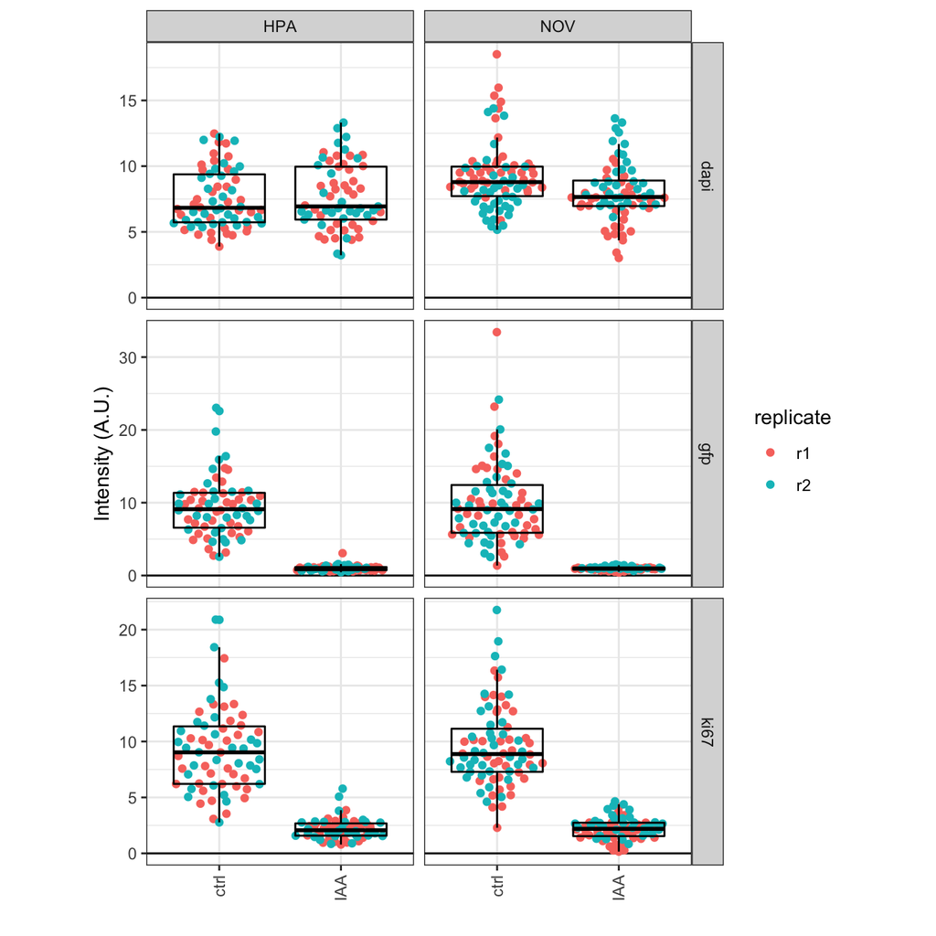

```r
# Also, normalize by cell volume
tib_gather %>%
  ggplot(aes(x = condition, y = value_norm, col = replicate)) +
  geom_hline(yintercept = 0, col = "black", linetype = "solid") +
  geom_quasirandom() +
  geom_boxplot(fill = NA, col = "black", outlier.shape = NA) +
  facet_grid(key ~ target, scales = "free_y") +
  xlab("") +
  ylab("Intensity (A.U.)") +
  theme_bw() +
  theme(aspect.ratio = 1,
        axis.text.x = element_text(angle = 90, vjust = 0.5, hjust=1))
```

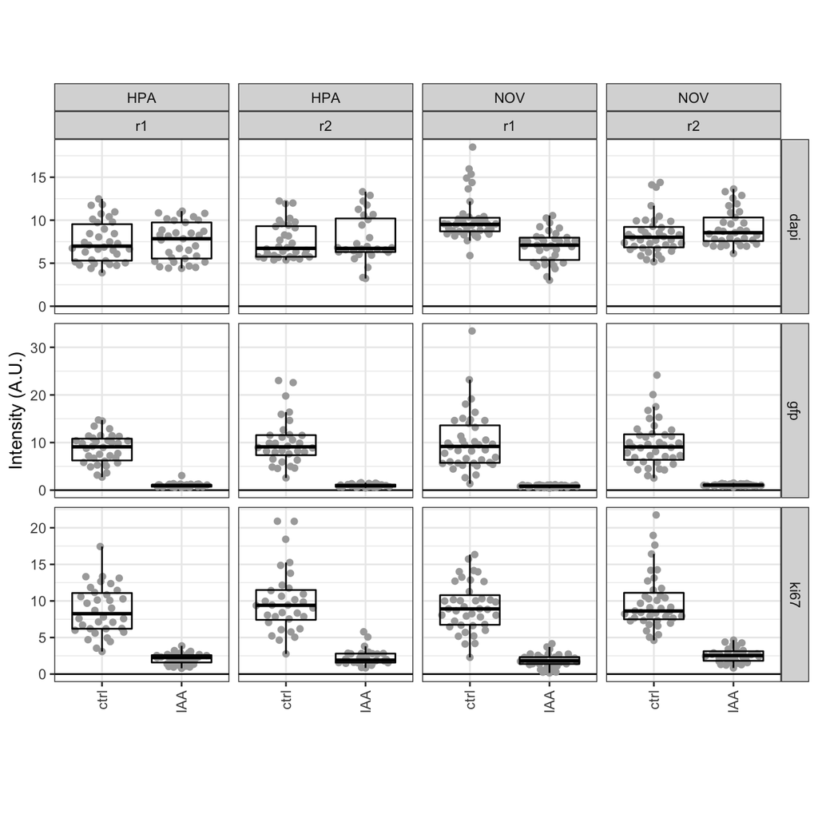

```r
tib_gather %>%
  ggplot(aes(x = condition, y = value_norm)) +
  geom_hline(yintercept = 0, col = "black", linetype = "solid") +
  geom_quasirandom(col = "darkgrey") +
  geom_boxplot(fill = NA, col = "black", outlier.shape = NA) +
  facet_grid(key ~ target + replicate, scales = "free_y") +
  xlab("") +
  ylab("Intensity (A.U.)") +
  theme_bw() +
  theme(aspect.ratio = 1,
        axis.text.x = element_text(angle = 90, vjust = 0.5, hjust=1))
```

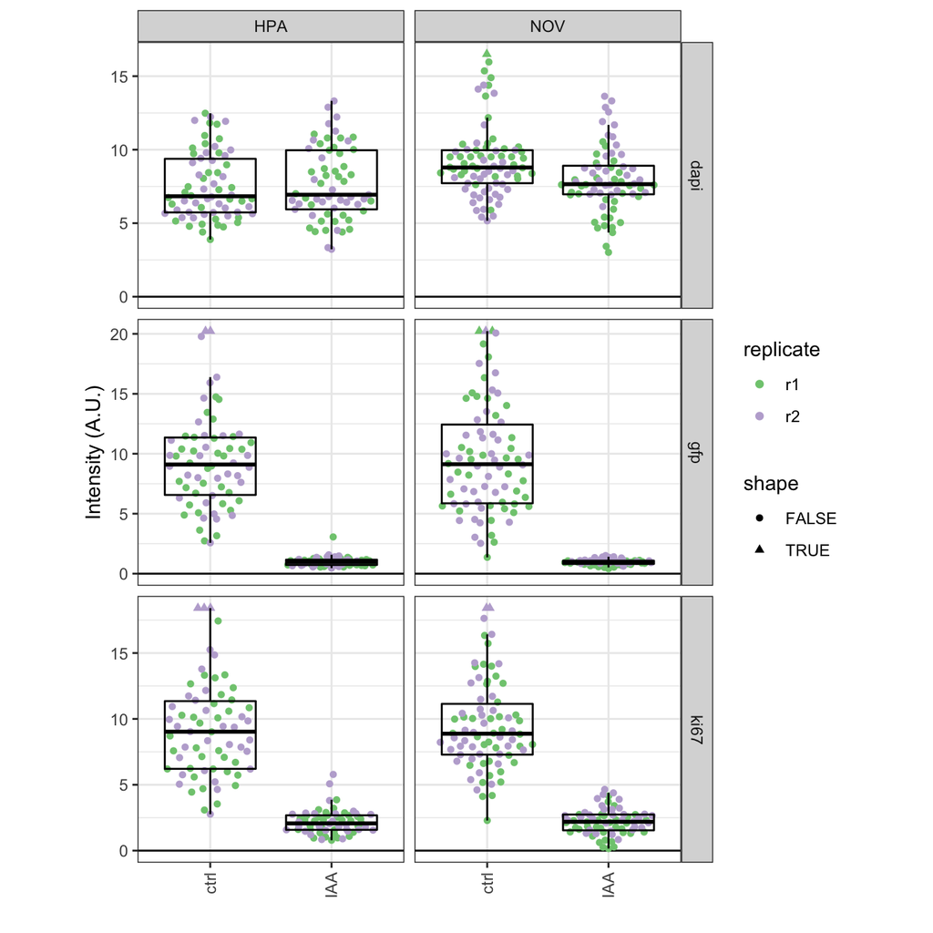

```r
# Also, remove outliers from plot
ylimits <- tib_gather %>%
  group_by(key) %>%
  dplyr::summarise(q95 = quantile(value_norm, 0.95) * 1.3)
ylimits_dapi <- ylimits$q95[ylimits$key == "dapi"]
ylimits_gfp <- ylimits$q95[ylimits$key == "gfp"]
ylimits_ki67 <- ylimits$q95[ylimits$key == "ki67"]

tib_gather %>%
  mutate(shape = case_when(key == "dapi" & value_norm > ylimits_dapi ~ T,
                           key == "gfp" & value_norm > ylimits_gfp ~ T,
                           key == "ki67" & value_norm > ylimits_ki67 ~ T,
                           T ~ F),
         value_norm = case_when(key == "dapi" & shape ~ ylimits_dapi,
                           key == "gfp" & shape ~ ylimits_gfp,
                           key == "ki67" & shape ~ ylimits_ki67,
                           T ~ value_norm)) %>%
  ggplot(aes(x = condition, y = value_norm, col = replicate)) +
  geom_hline(yintercept = 0, col = "black", linetype = "solid") +
  geom_quasirandom(aes(shape = shape)) +
  geom_boxplot(fill = NA, col = "black", outlier.shape = NA) +
  facet_grid(key ~ target, scales = "free_y") +
  xlab("") +
  ylab("Intensity (A.U.)") +
  scale_color_brewer(palette = "Accent") +
  theme_bw() +
  theme(aspect.ratio = 1,
        axis.text.x = element_text(angle = 90, vjust = 0.5, hjust=1))
```

### Conclusion

Several observations:

- Even though this analysis is only 2D-based, it convincingly shows that IAA strongly depletes Ki67. Never to the extend of the loss of GFP signal.
- Both antibodies are very similar in their extend of depletion. This effect size was also seen for the Abcam antibody.

Overall, this is a positive result and I should generate sequencing libraries to determine the effect of Ki67 knockdown on the two new antibodies. So far, so good.